# Assignment

Use the "from the expert" (FTE) jupyter notebook as a starter for this assignment, and ask your instructor questions if you need help.

Use the `churn_data.csv` file to carry out a similar data cleaning and preparation as we did in the FTE. Specifically, at least complete these minimum requirements:

- Check for outliers in numeric data, and deal with them if needed
- Check for missing values, and decide how to deal with them if needed
- Convert categorical columns to numeric values
- Create at least one new feature by combining multiple columns. For example, you could calculate the ratio of total charges to tenure. Create at least one plot for your new feature.
- Save the data to a csv (or another filetype of your choice) for use next week.
- Write a short analysis at the end of the notebook describing your findings and what you did.

You can do more data cleaning, preparation, and EDA beyond these basic requirements if you want to learn more and develop your data science skills. For example, you could use a box-cox transformation on the numeric data or try other outlier methods.

### DS process status

Here is our data science process, and where we are (#3):

**1. Business understanding**

Can we use machine learning to predict if a customer will churn before they leave?

**2. Data understanding**

Done in week 1 (mostly), this is iterative so you might do more of this as we go on.

**3. Data preparation**

We are here this week.

**4. Modeling**

Next week

**5. Evaluation**

Next week

**6. Deployment**

Next week

# Data Prepration

```python
import pandas as pd
from pandas_profiling import ProfileReport
import matplotlib.pyplot as plt

%matplotlib inline
```

```python
import numpy as np
```

```python
# we can give our index column a number or name but its's optional.
df = pd.read_csv('/Users/dikshyaupreti/downloads/churn_data.csv')
df
```

|  | customerID | tenure | PhoneService | Contract | PaymentMethod | MonthlyCharges | TotalCharges | Churn |
| --- | --- | --- | --- | --- | --- | --- | --- | --- |
| 0 | 7590-VHVEG | 1 | No | Month-to-month | Electronic check | 29.85 | 29.85 | No |
| 1 | 5575-GNVDE | 34 | Yes | One year | Mailed check | 56.95 | 1889.50 | No |
| 2 | 3668-QPYBK | 2 | Yes | Month-to-month | Mailed check | 53.85 | 108.15 | Yes |
| 3 | 7795-CFOCW | 45 | No | One year | Bank transfer (automatic) | 42.30 | 1840.75 | No |
| 4 | 9237-HQITU | 2 | Yes | Month-to-month | Electronic check | 70.70 | 151.65 | Yes |
| ... | ... | ... | ... | ... | ... | ... | ... | ... |
| 7038 | 6840-RESVB | 24 | Yes | One year | Mailed check | 84.80 | 1990.50 | No |
| 7039 | 2234-XADUH | 72 | Yes | One year | Credit card (automatic) | 103.20 | 7362.90 | No |
| 7040 | 4801-JZAZL | 11 | No | Month-to-month | Electronic check | 29.60 | 346.45 | No |
| 7041 | 8361-LTMKD | 4 | Yes | Month-to-month | Mailed check | 74.40 | 306.60 | Yes |
| 7042 | 3186-AJIEK | 66 | Yes | Two year | Bank transfer (automatic) | 105.65 | 6844.50 | No |

7043 rows × 8 columns

# Filtering

```python
#This is a crucial step of data prepration
df ['Churn'] == 'Churn'
```

```
0       False
1       False
2       False
3       False
4       False
        ...
7038    False
7039    False
7040    False
7041    False
7042    False
Name: Churn, Length: 7043, dtype: bool
```

```python
churn_df = df[df['Churn'] == 'Yes']
churn_df.head()
```

|  | customerID | tenure | PhoneService | Contract | PaymentMethod | MonthlyCharges | TotalCharges | Churn |
| --- | --- | --- | --- | --- | --- | --- | --- | --- |
| 2 | 3668-QPYBK | 2 | Yes | Month-to-month | Mailed check | 53.85 | 108.15 | Yes |
| 4 | 9237-HQITU | 2 | Yes | Month-to-month | Electronic check | 70.70 | 151.65 | Yes |
| 5 | 9305-CDSKC | 8 | Yes | Month-to-month | Electronic check | 99.65 | 820.50 | Yes |
| 8 | 7892-POOKP | 28 | Yes | Month-to-month | Electronic check | 104.80 | 3046.05 | Yes |
| 13 | 0280-XJGEX | 49 | Yes | Month-to-month | Bank transfer (automatic) | 103.70 | 5036.30 | Yes |

```python
#This command shows us the median for particular column for his we did Total Charges
TotalCharges_df = df[df['TotalCharges'] > df['TotalCharges'].median()]
TotalCharges_df.head()
```

|  | customerID | tenure | PhoneService | Contract | PaymentMethod | MonthlyCharges | TotalCharges | Churn |
| --- | --- | --- | --- | --- | --- | --- | --- | --- |
| 1 | 5575-GNVDE | 34 | Yes | One year | Mailed check | 56.95 | 1889.50 | No |
| 3 | 7795-CFOCW | 45 | No | One year | Bank transfer (automatic) | 42.30 | 1840.75 | No |
| 6 | 1452-KIOVK | 22 | Yes | Month-to-month | Credit card (automatic) | 89.10 | 1949.40 | No |
| 8 | 7892-POOKP | 28 | Yes | Month-to-month | Electronic check | 104.80 | 3046.05 | Yes |
| 9 | 6388-TABGU | 62 | Yes | One year | Bank transfer (automatic) | 56.15 | 3487.95 | No |

# Checking for outliers

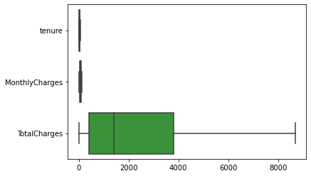

```python
# In this step we are checking the outliners to see what data go beyond the normal range

import seaborn as sns

sns.boxplot(data=df, orient='h')
```

```python
column = 'TotalCharges'
q1 = df[column].quantile(0.40)
q3 = df[column].quantile(0.80)
iqr = q3 - q1
upper_boundary = q3 + 1.5 * iqr
lower_boundary = q1 - 1.5 * iqr
df[(df[column] < lower_boundary) | (df[column] > upper_boundary)][column]
```

```
Series([], Name: TotalCharges, dtype: float64)
```

```python
import numpy as np
#Here we are making a copy of the data
df_copy = df.copy()
df_copy.at[df[column] < lower_boundary, column] = np.nan
df_copy.at[df[column] > upper_boundary, column] = np.nan
```

```python
df_copy = df.copy()
df_copy[column].clip(lower=lower_boundary, upper=upper_boundary, inplace=True)
```

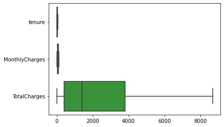

```python
sns.boxplot(data=df_copy, orient='h')
```